# 04-Data-Analysis

Analysis of accessibility to foodbanks in Hamilton.

Invoke data:

```r
load("output-data-files/data_da_2016.RData")
load("output-data-files/dwelling_network_points_2016.RData")
load("output-data-files/hamilton_boundary.RData")
load("output-data-files/population_age_income.RData")
load("output-data-files/foodbank_locations.RData")
load("output-data-files/modes_less40k.RData")
load("output-data-files/ttm_car.RData")
load("output-data-files/ttm_transit.RData")
load("output-data-files/ttm_walk.RData")
#data("data_da_2016")
#data("dwelling_network_points_2016")
#data("hamilton_cma")
#data("modes_less40k")
#data("foodbank_locations")
#data("ttm_car")
#data("ttm_transit")
#data("ttm_walk")
```

## Remove entries in travel time matrices for inapplicable destinations

As a first step, we will remove the computed travel times to the three Community Kitchen locations (IDs 1-3):

```r
ttm_car <- ttm_car %>%
  filter(!between(OBJECTID, left = 1, right = 3))

ttm_transit <- ttm_transit %>%
  filter(!between(OBJECTID, left = 1, right = 3))

ttm_walk <- ttm_walk %>%
  filter(!between(OBJECTID, left = 1, right = 3))
```

## Quick check

Distribution of the number of foodbanks that can be reached by each mode at the maximum travel time used in the calculation of the time matrices (180 min or 10,000 m).

Car:

```r
ttm_car %>% group_by(UID) %>% summarize(fb_per_parcel = n()) %>% summary()
```

```
      UID         fb_per_parcel
 Min.   :     1   Min.   :55
 1st Qu.: 38238   1st Qu.:55
 Median : 76514   Median :55
 Mean   : 76586   Mean   :55
 3rd Qu.:114343   3rd Qu.:55
 Max.   :155868   Max.   :55
```

All parcels can reach every foodbank within 180 min.

Transit:

```r
ttm_transit %>% group_by(UID) %>% summarize(fb_per_parcel = n()) %>% summary()
```

```
      UID         fb_per_parcel
 Min.   :     1   Min.   : 1.00
 1st Qu.: 38231   1st Qu.:48.00
 Median : 76654   Median :49.00
 Mean   : 76584   Mean   :48.59
 3rd Qu.:114283   3rd Qu.:52.00
 Max.   :155868   Max.   :52.00
```

Half of all parcels can reach 49 foodbanks or more in 180 min or less.

Walking:

```r
ttm_walk %>% group_by(UID) %>% summarize(fb_per_parcel = n()) %>% summary()
```

```
      UID         fb_per_parcel
 Min.   :     1   Min.   : 1.00
 1st Qu.: 38465   1st Qu.:17.00
 Median : 76627   Median :42.00
 Mean   : 76598   Mean   :32.38
 3rd Qu.:114129   3rd Qu.:44.00
 Max.   :155868   Max.   :51.00
```

Half of all parcels can reach 42 foodbanks or more in 180 min or less.

## Prepare data

Join number of low income households per DA to dwellings and total number of residential units:

```r
dwelling_network_points_2016 <- dwelling_network_points_2016 %>%
  left_join(data_da_2016 %>%
              st_drop_geometry() %>%
              dplyr::transmute(DAUID = GeoUID,
                               p_inc_less40k),
            by = "DAUID")
```

Calculate probability that a point on the network will have low income households. This is the proportion of low income households in the DA multiplied by the total number of residential units at the point:

```r
dwelling_network_points_2016 <- dwelling_network_points_2016 %>%
  mutate(income_less40k = p_inc_less40k * Dwellings)
```

Join the household data to the travel time matrices:

```r
ttm_car <- ttm_car %>%
  left_join(dwelling_network_points_2016 %>%
              st_drop_geometry() %>%
              dplyr::select(ID,
                            income_less40k,
                            DAUID,
                            TAZUID),
            by = c("UID" = "ID"))

ttm_transit <- ttm_transit %>%
  left_join(dwelling_network_points_2016 %>%
              st_drop_geometry() %>%
              dplyr::select(ID,
                            income_less40k,
                            DAUID,
                            TAZUID),
            by = c("UID" = "ID"))

ttm_walk <- ttm_walk %>%
  left_join(dwelling_network_points_2016 %>%
              st_drop_geometry() %>%
              dplyr::select(ID,
                            income_less40k,
                            DAUID,
                            TAZUID),
            by = c("UID" = "ID"))
```

Join the food bank data to the travel time matrices:

```r
ttm_car <- ttm_car %>%
  left_join(foodbank_locations %>%
              st_drop_geometry() %>%
              dplyr::select(ID,
                            TYPE,
                            COVIDClose),
            by = c("OBJECTID" = "ID"))

ttm_transit <- ttm_transit %>%
  left_join(foodbank_locations %>%
              st_drop_geometry() %>%
              dplyr::select(ID,
                            TYPE,
                            COVIDClose),
            by = c("OBJECTID" = "ID"))

ttm_walk <- ttm_walk %>%
  left_join(foodbank_locations %>%
              st_drop_geometry() %>%
              dplyr::select(ID,
                            TYPE,
                            COVIDClose),
            by = c("OBJECTID" = "ID"))
```

Drop NAs:

```r
ttm_car <- ttm_car %>%
  drop_na(TAZUID,
          income_less40k)

ttm_transit <- ttm_transit %>%
  drop_na(TAZUID,
          income_less40k)

ttm_walk <- ttm_walk %>%
  drop_na(TAZUID,
          income_less40k)
```

Calculate proportion of trips by mode per TAZ:

```r
modes <- modes_less40k %>%
  mutate(p_car = Driver/(Driver + Transit + Walk),
         p_transit = Transit/(Driver + Transit + Walk),
         p_walk = Walk/(Driver + Transit + Walk))
```

Assume that TAZ with NAs have a proportion of car trips of one:

```r
modes <- modes %>%
  dplyr::mutate(p_car = replace_na(p_car, 1),
                p_transit = replace_na(p_transit, 0),
                p_walk = replace_na(p_walk, 0))
```

```r
# join tripmaking modal proportions
ttm_car <- ttm_car %>%
  left_join(modes %>%
              st_drop_geometry() %>%
              transmute(TAZUID,
                        p_car,
                        p_transit,
                        p_walk),
            by = "TAZUID")

ttm_transit <- ttm_transit %>%
  left_join(modes %>%
              st_drop_geometry() %>%
              transmute(TAZUID,
                        p_car,
                        p_transit,
                        p_walk),
            by = "TAZUID")

ttm_walk <- ttm_walk %>%
  left_join(modes %>%
              st_drop_geometry() %>%
              transmute(TAZUID,
                        p_car,
                        p_transit,
                        p_walk),
            by = "TAZUID")
```

Join all tables:

```r
ttm <- ttm_car %>%
  rename(travel_time_car = travel_time) %>%
  full_join(ttm_transit %>%
              transmute(UID,
                        OBJECTID,
                        travel_time_transit = travel_time),
            by = c("UID", "OBJECTID")) %>%
  full_join(ttm_walk %>%
              transmute(UID,
                        OBJECTID,
                        travel_time_walk = travel_time),
            by = c("UID", "OBJECTID"))
```

Check the NAs in travel time table:

```r
ttm %>%
  filter(is.na(travel_time_transit)) %>%
  select(travel_time_transit,
         p_transit) %>%
  summary()
```

```
 travel_time_transit   p_transit
 Min.   : NA         Min.   :0.00000
 1st Qu.: NA         1st Qu.:0.00000
 Median : NA         Median :0.00000
 Mean   :NaN         Mean   :0.07332
 3rd Qu.: NA         3rd Qu.:0.10969
 Max.   : NA         Max.   :0.76724
 NA's   :981426
```

What does this mean? Most DAs missing travel time by transit do not report trips by transit in the TTS. In some DAs there are trips by transit (p_transit != 0), but no foodbank can be reached by transit (travel_time_transit is NA). How many of these cases?

```r
ttm %>%
  filter(is.na(travel_time_transit) & p_transit > 0) %>%
  select(travel_time_transit,
         p_transit) %>%
  summary()
```

```
 travel_time_transit   p_transit
 Min.   : NA         Min.   :0.02073
 1st Qu.: NA         1st Qu.:0.10969
 Median : NA         Median :0.19531
 Mean   :NaN         Mean   :0.21482
 3rd Qu.: NA         3rd Qu.:0.27651
 Max.   : NA         Max.   :0.76724
 NA's   :334976
```

It should be fine to replace the NAs with zeros, which multiplied by p_transit will return a zero (i.e., it is not possible to reach a foodbank by transit).

```r
ttm <- ttm %>%
  mutate(travel_time_transit = replace_na(travel_time_transit, 0))
```

Check the NAs in travel time by walk:

```r
ttm %>%
  filter(is.na(travel_time_walk)) %>%
  select(travel_time_walk,
         p_walk) %>%
  summary()
```

```
 travel_time_walk      p_walk
 Min.   : NA       Min.   :0.00000
 1st Qu.: NA       1st Qu.:0.00000
 Median : NA       Median :0.00000
 Mean   :NaN       Mean   :0.03637
 3rd Qu.: NA       3rd Qu.:0.03691
 Max.   : NA       Max.   :1.00000
 NA's   :3230980
```

What does this mean? Most DAs missing travel time by walking do not report trips by walking in the TTS. In some DAs there are trips by walking (p_walk != 0), but no foodbank can be reached by walk (travel_time_walk is NA). How many of these cases?

```r
ttm %>%
  filter(is.na(travel_time_walk) & p_walk > 0) %>%
  select(travel_time_walk,
         p_walk) %>%
  summary()
```

```
 travel_time_walk     p_walk
 Min.   : NA      Min.   :0.01675
 1st Qu.: NA      1st Qu.:0.04955
 Median : NA      Median :0.09911
 Mean   :NaN      Mean   :0.12449
 3rd Qu.: NA      3rd Qu.:0.17325
 Max.   : NA      Max.   :1.00000
 NA's   :943954
```

Like with transit, it should be fine to replace the NAs with zeros, which multiplied by p_walk will return a zero (i.e., it is not possible to reach a foodbank by walking).

```r
ttm <- ttm %>%
  mutate(travel_time_walk = replace_na(travel_time_walk, 0))
```

Summary of the table after these operations:

```r
summary(ttm)
```

[output not shown]

Calculate expected travel times by mode. These are the travel time by the mode multiplied by the probability of using the mode (which is proxied by the proportion of trips by mode in the DA from the TTS). The total expected travel time is the sum of the expected travel times by mode:

```r
ttm <- ttm %>%
  mutate(e_travel_time_car = travel_time_car * p_car,
         e_travel_time_transit = travel_time_transit * p_transit,
         e_travel_time_walk = travel_time_walk * p_walk,
         e_travel_time = e_travel_time_car + e_travel_time_transit + e_travel_time_walk)
```

What is the mean expected travel time for each parcel over all the foodbanks (open and closed)?

```r
e_travel_time_parcel <- ttm %>%
  group_by(UID) %>%
  summarize(DAUID = first(DAUID),
            e_travel_time = mean(e_travel_time))

summary(e_travel_time_parcel)
```

```
      UID            DAUID           e_travel_time
 Min.   :     1   Length:137994      Min.   : 7.618
 1st Qu.: 38326   Class :character   1st Qu.:17.073
 Median : 76620   Mode  :character   Median :20.646
 Mean   : 76660                      Mean   :22.699
 3rd Qu.:114414                      3rd Qu.:25.975
 Max.   :155868                      Max.   :72.228
```

Join geometry for plotting:

```r
e_travel_time_parcel <- e_travel_time_parcel %>%
  left_join(dwelling_network_points_2016 %>%
              select(ID, geometry),
            by = c("UID" = "ID")) %>%
  st_as_sf()
```

Plot:

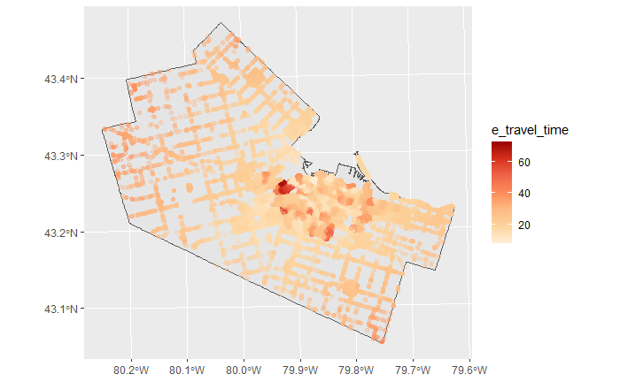

```r
ggplot() +
  geom_sf(data = hamilton_boundary) +
  geom_sf(data = e_travel_time_parcel,
          aes(color = e_travel_time),
          alpha = 0.3) +
  scale_color_distiller(palette = "OrRd", direction = 1)
```

What is the mean expected travel time for each parcel over all the foodbanks that did NOT close during COVID?

```r
e_travel_time_parcel_2 <- ttm %>%
  filter(COVIDClose == "No") %>%
  group_by(UID) %>%
  summarize(DAUID = first(DAUID),
            e_travel_time = mean(e_travel_time))

summary(e_travel_time_parcel_2)
```

```
      UID            DAUID           e_travel_time
 Min.   :     1   Length:137994      Min.   : 7.69
 1st Qu.: 38326   Class :character   1st Qu.:17.14
 Median : 76620   Mode  :character   Median :20.61
 Mean   : 76660                      Mean   :22.57
 3rd Qu.:114414                      3rd Qu.:25.74
 Max.   :155868                      Max.   :72.13
```

Join geometry for plotting:

```r
e_travel_time_parcel_2 <- e_travel_time_parcel_2 %>%
  left_join(dwelling_network_points_2016 %>%
              select(ID, geometry),
            by = c("UID" = "ID")) %>%
  st_as_sf()
```

Plot:

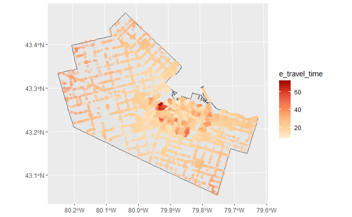

```r
ggplot() +
  geom_sf(data = hamilton_boundary) +
  geom_sf(data = e_travel_time_parcel_2,
          aes(color = e_travel_time),
          alpha = 0.3) +
  scale_color_distiller(palette = "OrRd", direction = 1)
```

Notice how expected travel time to all open food banks can *decrease* with the closures! Food banks on average are a little bit closer, but there are *fewer* of them, which will tend to increase the demand:

```r
summary(e_travel_time_parcel)
```

```
      UID            DAUID           e_travel_time             geometry
 Min.   :     1   Length:137994      Min.   : 7.618   POINT        :137994
 1st Qu.: 38326   Class :character   1st Qu.:17.073   epsg:26917   :     0
 Median : 76620   Mode  :character   Median :20.646   +proj=utm ...:     0
 Mean   : 76660                      Mean   :22.699
 3rd Qu.:114414                      3rd Qu.:25.975
 Max.   :155868                      Max.   :72.228
```

```r
summary(e_travel_time_parcel_2)
```

```
      UID            DAUID           e_travel_time            geometry
 Min.   :     1   Length:137994      Min.   : 7.69   POINT        :137994
 1st Qu.: 38326   Class :character   1st Qu.:17.14   epsg:26917   :     0
 Median : 76620   Mode  :character   Median :20.61   +proj=utm ...:     0
 Mean   : 76660                      Mean   :22.57
 3rd Qu.:114414                      3rd Qu.:25.74
 Max.   :155868                      Max.   :72.13
```